# Solutions 2: Compartmental Models to Equations

Sam Abbott

# Learning Objectives

1. Know how to translate a simple model flow diagram into equations.
2. Understand how changing parameter values can change model dynamics.
3. Know how to use a simple model scaffold to develop a more complex model.

# Outline for Session

1. Set up (5 minutes)
2. Explore the dynamics of a simple SEIR model (10 minutes)
3. Add high and low risk latency to a SEIR model (10 minutes)
4. Explore SHLIR model dynamics and compare to the SEIR model (10 minutes)
5. Extension: Translate a more realistic SHLIR model flow diagram to equations (25 minutes)
6. Extension: Explore the parameter space of multiple models (25 minutes)(If having trouble with the previous exercises then skip to this point for an R free exercise)
7. Session wrap up (5 minutes)

# Excercises

## 1. A Simple SEIR Model of Tuberculosis (TB)

As a first exercise we are going to run the simple SEIR model, as seen in the design a model practical, in R. As a first step you will need to load the following packages.

```r
library(biddmodellingcourse)
library(tidyverse)
library(knitr)
library(prettypublisher)
```

For reference the SEIR model flow diagram ([1]) seen in the first practical. The equations below are a translation of this into `R` code.

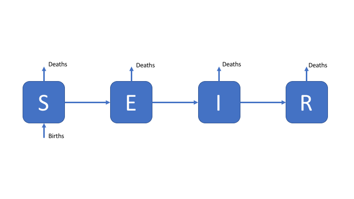

Figure 1: An SEIR model of TB transmission, including simple demographic processes

### Populations and Initialisation

We first set up the initial populations for the Susceptible ($S_0$), Latent ($E_0$), Infected ($I$), and Recovered ($R$) compartments. We have initialised the model as an early stage epidemic with a single case of TB.

```r
inits = c(
  S = 999,
  E = 0,
  I = 1,
  R = 0
)
```

### Parameters

We then specify the model parameters (with the units being years<sup>-1</sup>), varying these parameters will impact the model dynamics.

```r
parameters <- c(
  beta = 3, # Rate of transmission
  gamma = 1/5, # Rate of progression to active symptoms
  tau = 1/2, # Rate of recovery
  mu = 1/81 # Rate of natural mortality
)
```

### Equations

Finally we specify the model equations for each population compartment. This is model incorporates simple demographic processes with a constant natural death rate from all compartments which is equal to the birth rate into the susceptible compartment.

```r
SEIR_demo_ode <- function(t, x, params) {

  ## Specify model compartments
  S <- x[1]
  E <- x[2]
  I <- x[3]
  R <- x[4]

  with(as.list(params),{

    ## Specify total population
    N = S + E + I + R

    ## Derivative Expressions
    dS = - beta * S * I / N - mu * S + mu * N
    dE = beta * S * I / N - gamma * E - mu * E
    dI = gamma * E - tau * I - mu * I
    dR = tau * I - mu * R

    ## output
    derivatives <- c(dS, dE, dI, dR)

    list(derivatives)
  })
}
```

### Simulate and Summarise

To simulate the model we specify the starting year (`begin_time`) and final year (`end_time`) and define a sequence over all intervening years. The model is then solved using `deSolve::lsoda` which is used within a simple wrapper function (see `?solve_ode` for details). The resulting table summarises the simulation results for the first 5 years.

```r
begin_time <- 0
end_time <- 200
times <- seq(begin_time, end_time, 1)

## see ?solve_ode for details
SEIR_sim <- biddmodellingcourse::solve_ode(model = SEIR_demo_ode,
                                           inits = inits,
                                           params = parameters,
                                           times = times,
                                           as.data.frame = TRUE)
SEIR_sim %>%
  head %>%
  pretty_table(caption = "First 5 years of model simulation",
               label = "tab-1")
```

Table 1: First 5 years of model simulation

| time | S | E | I | R |
| --- | --- | --- | --- | --- |
| 0 | 999 | 0 | 1 | 0 |
| 1 | 996.5 | 2.306 | 0.8082 | 0.4264 |
| 2 | 993.9 | 4.253 | 1.008 | 0.8608 |
| 3 | 990.4 | 6.724 | 1.468 | 1.455 |
| 4 | 985.1 | 10.32 | 2.219 | 2.34 |
| 5 | 977.2 | 15.71 | 3.373 | 3.681 |

We then summarise the epidemic peak (`epi_peak`) and epidemic duration (`epi_dur`), along with population sizes at the end of the time period simulated.

```r
biddmodellingcourse::summarise_model(SEIR_sim) %>%
  pretty_table(caption = "SEIR model summary statistics; The final size of each population at the end of the simulation, along with the time the epidemic peak was reached, the number of infected at the epidemic peak and the duration of the epidemic")
```

Table 2: SEIR model summary statistics; The final size of each population at the end of the simulation, along with the time the epidemic peak was reached, the number of infected at the epidemic peak and the duration of the epidemic

| S | E | I | R | epi_peak_time | epi_peak_size | epi_dur |
| --- | --- | --- | --- | --- | --- | --- |
| 181 | 47 | 18 | 753 | 18 | 141 | 1 |

Finally we plot the population in each model compartment over time.

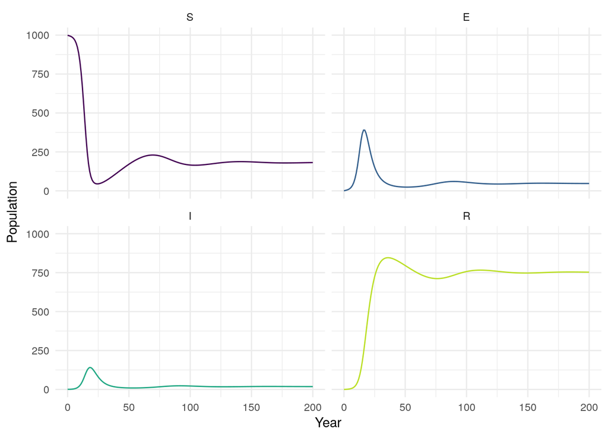

Figure 2: Plot of population over time in each SEIR model compartment

```r
## For an interactive graph change interactive to TRUE
biddmodellingcourse::plot_model(SEIR_sim, interactive = FALSE)
```

### Explore

Model dynamics are parameter dependent. Even in a simplistic model like the one outlined above parameter values can greatly alter the dynamics. Answer the following questions by varying the parameters above and rerunning the model.

1. What is the impact of adding demographic processes (births and deaths)?
   - Without demograpic processes Tuberculosis eventually dies out. The addition of demographic processes results in a continous supply of susceptibles that makes this less likely to happen. However if the disease is sufficiently infectious and has a short serial interval then even with demographic processes the supply of new susceptibles may run out, resulting in the disease dieing out.
2. What happens when the transmission rate (beta) is reduced to 0.5?
   - When the transmission rate is reduced to 0.5 Tuberculosis will die out without spreading any further than the index case. This is because the basic reproduction number is below 1 for this set of parameters.
3. What happens as the rate of recovery is increased?
   - As the rate of recovery is increased the size of the epidemic peak is decreased and the duration of the epidemic increases. The cumulative number of cases is reduced.

## 2. Add High and Low Risk Compartments

We are now going to make the model slightly more realistic, and therefore better able to capture the observed dynamics of TB. We are going to do this by adding a second latent population, this change can be seen in the model flow diagram (Figure 3). Go back to [practical 1](https://bristolmathmodellers.github.io/biddmodellingcourse/articles/practical_1.html) if you need a refresher for the motivation behind this.

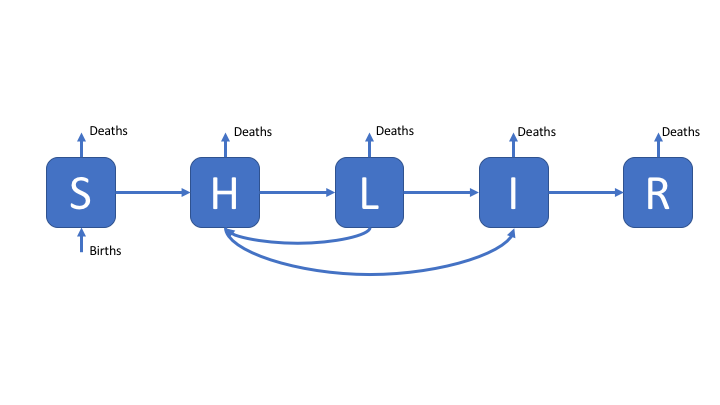

Figure 3: An SHLIR model of TB transmission, including simple demographic processes

### Populations and Initialisation

As in the previous model the first step is to define the model populations. There are now two new compartments, high risk latents (H), and low risk latents (L). These replace the original latent population (E) used in the previous model.

```r
SHLIR_inits = c(
  S = 999,
  H = 0,
  L = 0,
  I = 1,
  R = 0
)
```

### Parameters

We add two additional parameters for the rate of progression from high to low risk latents (`nu`) and the rate of progression from low risk latent to active disease (`gamma_L`).

```r
SHLIR_parameters <- c(
  beta = 3, # Rate of transmission
  gamma_H = 1/5, # Rate of progression to active symptoms from high risk latent
  nu = 1/2, #Rate of progression from high to low risk latent
  gamma_L = 1/100, # Rate of progression to active symptoms for low risk latent
  tau = 1/2, # Rate of recovery
  mu = 1/81 # Rate of natural mortality
)
```

### Equations

The code below is a starting point, fill in the missing model terms using the model flow diagram (Figure 3) and the code for the previous SEIR model as reference points.

```r
SHLIR_demo_ode <- function(t, x, params) {

  ## Specify model compartments
  S <- x[1]
  H <- x[2]
  L <- x[3]
  I <- x[4]
  R <- x[5]

  with(as.list(params),{

    ## Specify total population
    N = S + H + L + I + R

    ## Derivative Expressions
    dS = - beta * S * I / N - mu * S + mu * N
    ## These are the new equations - fill in the remaining terms
    dH = beta * (S + L) * I / N - gamma_H * H - nu * H - mu * H
    dL = nu * H - beta * L * I / N - gamma_L * L - mu * L
    ## Hint terms are missing from this equation as well
    dI = gamma_H * H + gamma_L * L - tau * I - mu * I
    dR = tau * I - mu * R

    ## output
    derivatives <- c(dS, dH, dL, dI, dR)

    list(derivatives)
  })
}
```

### Simulate and Summarise

Simulation is the same as for the previous model. Does the simulation of your improved model make sense? Evaluate the summary tables and plot of model populations over time.

```r
begin_time <- 0
end_time <- 200
SHILR_times <- seq(begin_time, end_time, 1)

## see ?solve_ode for details
SHLIR_sim <- biddmodellingcourse::solve_ode(model = SHLIR_demo_ode,
                                           inits = SHLIR_inits,
                                           params = SHLIR_parameters,
                                           times = SHILR_times,
                                           as.data.frame = TRUE)
SHLIR_sim %>%
  head %>%
  pretty_table(caption = "First 5 years of SHLIR model simulation",
               label = "tab-1")
```

[output not shown]

```r
biddmodellingcourse::summarise_model(SHLIR_sim) %>%
  pretty_table(caption = "SHLIR model summary statistics; The final size of each population at the end of the simulation, along with the time the epidemic peak was reached, the number of infected at the epidemic peak and the duration of the epidemic")
```

[output not shown]

```r
## For an interactive graph change interactive to TRUE
biddmodellingcourse::plot_model(SHLIR_sim, interactive = FALSE)
```

[output not shown]

## Explore

1. Test your changes by setting `nu = 0` and all other parameters to be the same as for the SEIR model. If everything is working correctly both models should give the same output.
   - This works because when `nu = 0` no one enters the low risk latent population compartment and therefore it has no effect.
2. What has the impact of adding the second latent population been?
   - It has reduced the peak epidemic size and slowed the initial spread of the disease. In addition there are fewer cumulative active cases but a larger pool of latently infected cases.

## Extension: Translate a more realistic SHLIR model flow diagram to equations

As an advanced extension exercise now translate a more complex SHLIR model flow diagram (Figure 4), with risk groups, treatment, and reinfection for those who have recovered from active disease (Hint: First implement the model without risk groups and then add this in once everything else is working as expected). Whilst many realistic TB models use age structure in the interests of time do not include this (if you are interested in discussing how you would include this talk to your instructors or contact [me](https://www.samabbott.co.uk/)).

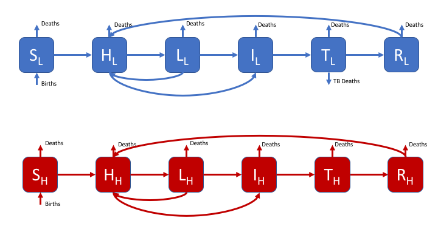

Figure 4: A realistic SHLIR model of TB transmission, including simple demographic processes

Figure 4 does not include the interaction between the high and low risk subgroups as this is through the force of infection. The force of infection is defined as,

$$\lambda_i = \beta \sum_{j = L, H}M_{ij}I_j$$

Where $\lambda_i$ is the force of infection in each risk group ($i = L, H$) and $M_{LH}$ is the mixing rate between risk groups. It is assumed that within group contact rates are equivalent and defined such that,

$$M_{ii} = 1$$

The code for an SEIR model has been supplied, along with all the required simulation and plotting functions. It is suggested that you add complexity sequentially and test the effects on the model dynamics as you go. The first step is to recreate the SHLIR model used above. If you are new to `R` or are struggling with this exercise feel free to move on to the next exercise (which does not use `R`).

### Populations and Initialisation

Add new compartments you want to define here, in most circumstances these should be initialised with 0 population. The population should be split between low and high risk populations, with the only infectious case being in the high risk population.

```r
real_SHLIR_inits = c(
  # General population
  S = 800,
  H = 0,
  L = 0,
  I = 0,
  Tr = 0,
  R = 0,
  ## High risk population
  S_H = 199,
  H_H = 0,
  L_H = 0,
  I_H = 1,
  Tr_H = 0,
  R_H = 0
)
```

### Parameters

Specify new model parameters here (with the units being years<sup>-1</sup>). The names of the new parameters will need to match those used in the model equations. The only new parameter for the high risk group should be a high risk beta (`beta_H` for example). The between group mixing (`M`) has been defined for you, as has the proportion that are born high risk (`p`).

```r
real_SHLIR_parameters <- c(
  beta = 3, # Rate of transmission
  beta_H = 6, # High risk rate of transmission
  gamma_H = 1/5, # Rate of progression to active symptoms from high risk latent
  nu = 1/2, #Rate of progression from high to low risk latent
  gamma_L = 1/100, # Rate of progression to active symptoms for low risk latent
  epsilon = 1/3, # Rate of treatment
  tau = 1/2, # Rate of recovery
  mu = 1/81, # Rate of natural mortality
  p = 0.2, # proportion of new births that are high risk
  M = 0.2 # Between group mixing
)
```

### Equations

Update the simple SEIR model equations using the model flow diagram above. The comments in the code given hints as to where changes need to be made.

```r
real_SHLIR_demo_ode <- function(t, x, params) {

  ## Specify model compartments - new model compartments need to be added here
  ## Add compartments in the order they appear in your model flow diagram
  ## Don't forget to update indexing for x. Compare the previous two models for a hint.
  S <- x[1]
  H <- x[2]
  L <- x[3]
  I <- x[4]
  Tr <- x[5]
  R <- x[6]

  S_H <- x[7]
  H_H <- x[8]
  L_H <- x[9]
  I_H <- x[10]
  Tr_H <- x[11]
  R_H <- x[12]

  with(as.list(params),{

    ## Specify total population - add new compartments here
    ## If this isn't working you simulations will likely blow up over time!
    N = S + H + L + I + Tr + R + S_H + H_H + L_H + I_H + Tr_H + R_H

    # Force of infection
    foi <- beta  * I / N + M * beta_H * I_H / N
    foi_H <-  M * beta  * I / N +  beta_H * I_H / N

    ## Derivative Expressions
    # Again new compartments here along with new model terms
    # Don't forget to add any new model terms for existing compartments
    ## General population
    dS = - S * foi - mu * S + (1 - p) * mu * N
    dH = (S + L + R) * foi - gamma_H * H - nu * H - mu * H
    dL = nu * H - L * foi - gamma_L * L - mu * L
    dI = gamma_H * H + gamma_L * L - epsilon * I - mu * I
    dTr = epsilon * I - tau * Tr - mu * Tr
    dR = tau * Tr - R * foi - mu * R

    ## High risk population
    dS_H = - S_H * foi_H - mu * S_H + p * mu * N
    dH_H = (S_H + L_H + R_H) * foi_H - gamma_H * H_H - nu * H_H - mu * H_H
    dL_H = nu * H_H - L_H * foi_H - gamma_L * L_H - mu * L_H
    dI_H = gamma_H * H_H + gamma_L * L_H - epsilon * I_H - mu * I_H
    dTr_H = epsilon * I_H - tau * Tr_H - mu * Tr_H
    dR_H = tau * Tr_H - R_H * foi_H - mu * R_H

    ## output
    # Finally  add your new derivative equations here
    # These need to be in the same order as you specified for the model compartments!
    # If this is wrong it is likely your results will look nothing like the previous models!
    derivatives <- c(dS, dH, dL, dI, dTr, dR, dS_H, dH_H, dL_H, dI_H, dTr_H, dR_H)

    list(derivatives)
  })
}
```

### Simulate and Summarise

Simulate the new model as previously.

```r
begin_time <- 0
end_time <- 200
real_SHLIR_times <- seq(begin_time, end_time, 1)

## see ?solve_ode for details
real_SHLIR_sim <- biddmodellingcourse::solve_ode(model = real_SHLIR_demo_ode,
                                           inits = real_SHLIR_inits,
                                           params = real_SHLIR_parameters,
                                           times = real_SHLIR_times,
                                           as.data.frame = TRUE)
real_SHLIR_sim %>%
  head %>%
  pretty_table(caption = "First 5 years of model simulation",
               label = "tab-real_SHLIR")
```

[output not shown]

```r
biddmodellingcourse::summarise_model(real_SHLIR_sim) %>%
  pretty_table(caption = "Realistic SHLIR model summary statistics; The final size of each population at the end of the simulation, along with the time the epidemic peak was reached, the number of infected at the epidemic peak and the duration of the epidemic")
```

[output not shown]

```r
## For an interactive graph change interactive to TRUE
biddmodellingcourse::plot_model(real_SHLIR_sim, interactive = FALSE)
```

[output not shown]

## Extension: Explore the Parameter Space of Multiple Models

In order to more systematically explore the parameter space of multiple models we have provided a web app (http://seabbs.co.uk/shiny/exploreidmodels/). Use this to explore the models discussed above and identify which parameters alter the model dynamics. What commonalities are there between different models and what generalisations can you draw from this.

## Using the Web App

- Go to http://seabbs.co.uk/shiny/exploreidmodels/. You should see the following:

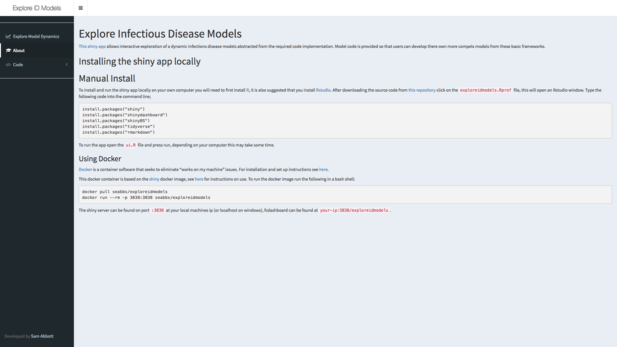

Figure 5: Homepage for the Explore Infectious Disease web app.

- Click on the Explore Model Dynamics tab in the menu on the left hand side. The app will now look like this:

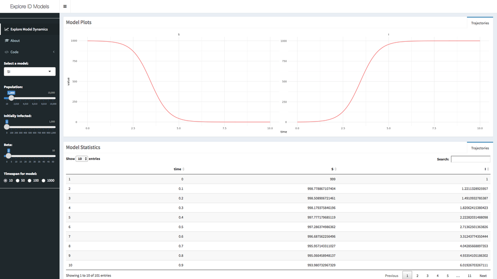

Figure 6: Explore Model Dynamics tab for the Explore Infectious Disease web app.

- Select a model of interest from the menu, options include: SI, SEI, SEIR, and SHLIR, with or without demographic processes.

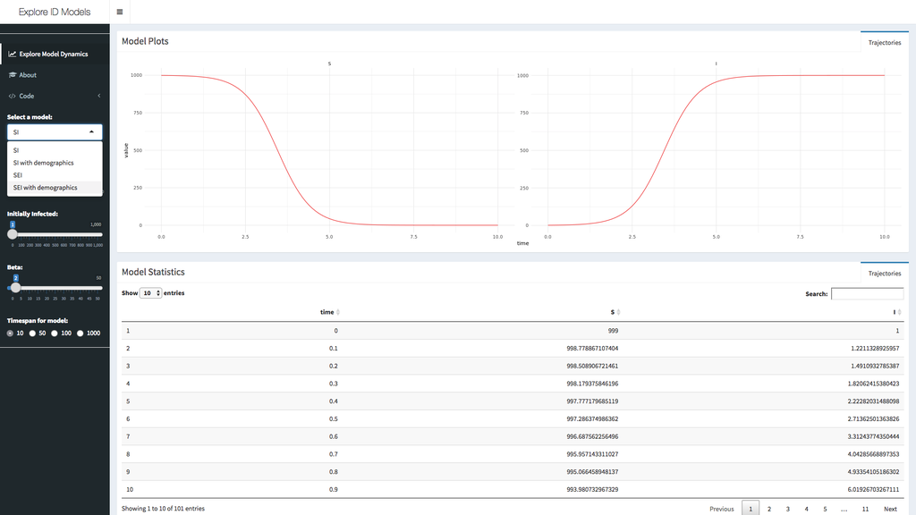

Figure 7: Select a model in the Explore Infectious Disease web app.

- Now vary parameter values using the provided sliders in the menu, you should observe the population in each compartment changing over time. Both summary tables used in the exercises above are also provided.

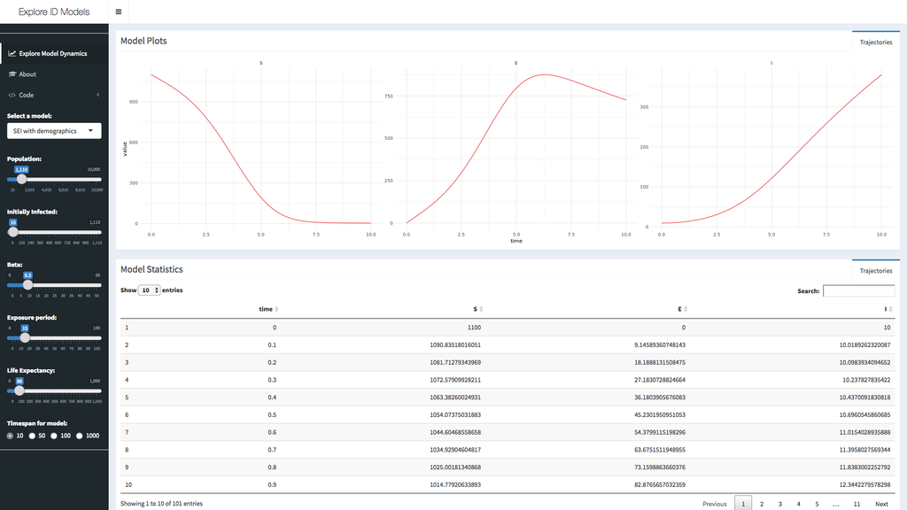

Figure 8: Vary parameters to explore dynamics in the Explore Infectious Disease web app.

# References

1 Brooks-Pollock E, Cohen T, Murray M. The impact of realistic age structure in simple models of tuberculosis transmission. *PLoS One* 2010;**5**:3–8. doi:10.1371/journal.pone.0008479